# DRC M23 Conflict and Internally Displaced Population Analysis

# 5. Prediction

## 5-1. Regression

```
##
## Call:
## lm(formula = formula_lm, data = M23_laglead_imputed)
##
## Residuals:
##     Min      1Q  Median      3Q     Max
## -204717 -129477  -66853    2850 4411677
##
## Coefficients:
##                            Estimate Std. Error t value Pr(>|t|)
## (Intercept)               7.972e+03  4.328e+04   0.184    0.854
## nconflicts                5.728e+03  2.721e+04   0.211    0.833
## fatalities               -1.442e+02  9.859e+02  -0.146    0.884
## civilian_targeting        8.067e+04  6.484e+05   0.124    0.901
## nconflicts_lag1           1.192e+04  9.316e+04   0.128    0.898
## nconflicts_lag2           6.569e+04  1.293e+05   0.508    0.611
## nconflicts_lag3          -1.974e+04  1.167e+05  -0.169    0.866
## nconflicts_lag4          -1.072e+05  2.628e+05  -0.408    0.684
## nconflicts_lag5           1.440e+05  1.690e+05   0.852    0.395
## nconflicts_lag6          -1.309e+05  1.345e+05  -0.973    0.331
## fatalities_lag1          -1.312e+03  9.267e+03  -0.142    0.887
## fatalities_lag2          -6.800e+03  2.522e+04  -0.270    0.787
## fatalities_lag3          -8.656e+03  3.021e+04  -0.287    0.775
## fatalities_lag4           1.436e+04  2.060e+04   0.697    0.486
## fatalities_lag5          -4.394e+03  2.065e+04  -0.213    0.831
## fatalities_lag6           6.831e+03  2.200e+04   0.310    0.756
## civilian_targeting_lag1   2.873e+05  4.022e+06   0.071    0.943
## civilian_targeting_lag2   4.236e+06  1.848e+07   0.229    0.819
## civilian_targeting_lag3  -6.208e+05  1.939e+07  -0.032    0.974
## civilian_targeting_lag4  -5.875e+06  2.501e+07  -0.235    0.814
## civilian_targeting_lag5  -2.584e+06  1.433e+07  -0.180    0.857
## civilian_targeting_lag6   1.621e+06  7.214e+06   0.225    0.822
## nconflicts_lead1         -1.282e+04  8.197e+04  -0.156    0.876
## nconflicts_lead2          4.757e+04  1.548e+05   0.307    0.759
## nconflicts_lead3         -1.443e+05  1.495e+05  -0.965    0.335
## nconflicts_lead4         -1.362e+03  2.145e+05  -0.006    0.995
## nconflicts_lead5          5.594e+02  1.648e+05   0.003    0.997
## nconflicts_lead6          1.512e+05  2.024e+05   0.747    0.455
## fatalities_lead1         -2.562e+03  5.717e+03  -0.448    0.654
## fatalities_lead2         -6.073e+02  4.657e+03  -0.130    0.896
## fatalities_lead3          3.935e+03  2.176e+04   0.181    0.857
## fatalities_lead4         -8.098e+03  1.739e+04  -0.466    0.642
## fatalities_lead5          2.137e+03  2.181e+04   0.098    0.922
## fatalities_lead6          5.022e+03  1.701e+04   0.295    0.768
## civilian_targeting_lead1  3.898e+05  3.339e+06   0.117    0.907
## civilian_targeting_lead2  5.924e+04  1.459e+07   0.004    0.997
## civilian_targeting_lead3 -9.400e+05  1.472e+07  -0.064    0.949
## civilian_targeting_lead4 -8.759e+06  1.810e+07  -0.484    0.629
## civilian_targeting_lead5  2.254e+07  3.714e+07   0.607    0.544
## civilian_targeting_lead6 -1.068e+07  1.531e+07  -0.698    0.486
##
## Residual standard error: 347100 on 1325 degrees of freedom
##   (188 observations deleted due to missingness)
## Multiple R-squared:  0.04142,    Adjusted R-squared:  0.0132
## F-statistic: 1.468 on 39 and 1325 DF,  p-value: 0.03241
```

```
##               nconflicts               fatalities       civilian_targeting
##                598.97249                103.99527                 56.13896
##          nconflicts_lag1          nconflicts_lag2          nconflicts_lag3
##               7156.41309              13841.58660              11216.04641
##          nconflicts_lag4          nconflicts_lag5          nconflicts_lag6
##              56848.61540              23336.77942              14644.88406
##          fatalities_lag1          fatalities_lag2          fatalities_lag3
##               8946.93758              66530.99582              95259.07765
##          fatalities_lag4          fatalities_lag5          fatalities_lag6
##              43983.39942              44468.74423              50409.02590
##  civilian_targeting_lag1  civilian_targeting_lag2  civilian_targeting_lag3
##               2094.95005              41618.87509              45680.95623
##  civilian_targeting_lag4  civilian_targeting_lag5  civilian_targeting_lag6
##              76263.46229              25775.82699               6389.92866
##         nconflicts_lead1         nconflicts_lead2         nconflicts_lead3
##               5539.46898              19828.69055              18276.65413
##         nconflicts_lead4         nconflicts_lead5         nconflicts_lead6
##              38054.45513              22154.88419              33368.66016
##         fatalities_lead1         fatalities_lead2         fatalities_lead3
##               3442.00657               2279.78789              49379.88985
##         fatalities_lead4         fatalities_lead5         fatalities_lead6
##              31416.43204              49622.58930              30173.91265
## civilian_targeting_lead1 civilian_targeting_lead2 civilian_targeting_lead3
##               1470.65795              26278.15888              26337.85086
## civilian_targeting_lead4 civilian_targeting_lead5 civilian_targeting_lead6
##              39814.17018             170511.44395              28691.63089
```

The linear regression model demonstrates poor performance and limited utility for inference or prediction. The R-squared is only 0.041, indicating that the model explains just 4.1% of the variance in displacement, and the adjusted R-squared drops to 0.013, suggesting that the inclusion of many predictors does not meaningfully improve explanatory power and may instead reflect overfitting. Moreover, none of the current, lagged, or lead conflict-related variables are statistically significant, with nearly all p-values well above conventional thresholds. Several coefficients—particularly those related to civilian targeting—exhibit extremely large standard errors, pointing to issues of multicollinearity, data sparsity, and overparameterization. Together, these issues indicate that the model is unstable and unsuitable for drawing substantive conclusions.

## 5-2. Machine Learning Model

### 5-2-1 LASSO

#### Prepare data

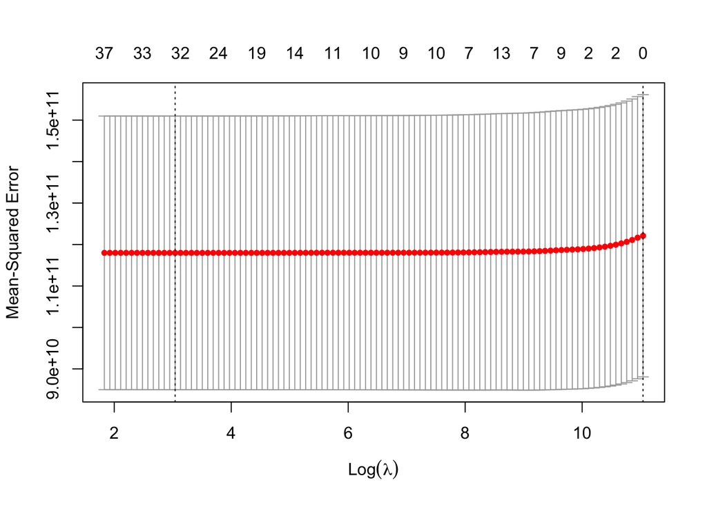

```
## 40 x 1 sparse Matrix of class "dgCMatrix"
##                                     s1
## (Intercept)              -1.231728e+04
## nconflicts                2.441975e+03
## fatalities                7.342915e+00
## civilian_targeting       -2.260219e+03
## nconflicts_lag1           4.905615e+03
## nconflicts_lag2           .
## nconflicts_lag3          -4.384448e+01
## nconflicts_lag4           1.543801e+00
## nconflicts_lag5           1.176629e+03
## nconflicts_lag6          -1.079115e+02
## fatalities_lag1           6.064543e+00
## fatalities_lag2          -2.188781e+01
## fatalities_lag3          -5.622699e+01
## fatalities_lag4          -3.304113e+02
## fatalities_lag5           6.388575e-02
## fatalities_lag6           8.075737e-02
## civilian_targeting_lag1   2.283638e+05
## civilian_targeting_lag2  -9.111314e+04
## civilian_targeting_lag3  -1.976794e+05
## civilian_targeting_lag4   .
## civilian_targeting_lag5   1.800801e+04
## civilian_targeting_lag6   .
## nconflicts_lead1         -1.771320e+02
## nconflicts_lead2          .
## nconflicts_lead3          .
## nconflicts_lead4          .
## nconflicts_lead5          2.530317e+03
## nconflicts_lead6          .
## fatalities_lead1          1.199289e+02
## fatalities_lead2         -3.281423e+00
## fatalities_lead3         -1.642263e+01
## fatalities_lead4         -4.263748e-02
## fatalities_lead5          1.118493e+00
## fatalities_lead6         -5.229995e-01
## civilian_targeting_lead1  3.950369e+05
## civilian_targeting_lead2  1.702841e+03
## civilian_targeting_lead3 -1.134959e+05
## civilian_targeting_lead4 -1.499070e+05
## civilian_targeting_lead5  .
## civilian_targeting_lead6 -2.751685e+05
```

```
## 40 x 1 sparse Matrix of class "dgCMatrix"
##                                     s1
## (Intercept)              -1.231728e+04
## nconflicts                2.441975e+03
## fatalities                7.342915e+00
## civilian_targeting       -2.260219e+03
## nconflicts_lag1           4.905615e+03
## nconflicts_lag2           .
## nconflicts_lag3          -4.384448e+01
## nconflicts_lag4           1.543801e+00
## nconflicts_lag5           1.176629e+03
## nconflicts_lag6          -1.079115e+02
## fatalities_lag1           6.064543e+00
## fatalities_lag2          -2.188781e+01
## fatalities_lag3          -5.622699e+01
## fatalities_lag4          -3.304113e+02
## fatalities_lag5           6.388575e-02
## fatalities_lag6           8.075737e-02
## civilian_targeting_lag1   2.283638e+05
## civilian_targeting_lag2  -9.111314e+04
## civilian_targeting_lag3  -1.976794e+05
## civilian_targeting_lag4   .
## civilian_targeting_lag5   1.800801e+04
## civilian_targeting_lag6   .
## nconflicts_lead1         -1.771320e+02
## nconflicts_lead2          .
## nconflicts_lead3          .
## nconflicts_lead4          .
## nconflicts_lead5          2.530317e+03
## nconflicts_lead6          .
## fatalities_lead1          1.199289e+02
## fatalities_lead2         -3.281423e+00
## fatalities_lead3         -1.642263e+01
## fatalities_lead4         -4.263748e-02
## fatalities_lead5          1.118493e+00
## fatalities_lead6         -5.229995e-01
## civilian_targeting_lead1  3.950369e+05
## civilian_targeting_lead2  1.702841e+03
## civilian_targeting_lead3 -1.134959e+05
## civilian_targeting_lead4 -1.499070e+05
## civilian_targeting_lead5  .
## civilian_targeting_lead6 -2.751685e+05
```